# Lab 4 Normal Distribution

In this lab, you’ll investigate the probability distribution that is most central to statistics: the normal distribution. If you are confident that your data are nearly normal, that opens the door to many powerful statistical methods. Here we’ll use the graphical tools of R to assess the normality of our data and also learn how to generate random numbers from a normal distribution.

Statistician like to create simplified models to represent real world data. The normal distribution function is a model used to represent a numerical variable with **bell shape** distribution. The advantage of the normal distribution function is that only 2 parameters are needed represent the entire distribution.

The normal distribution function is an exponential function of base **e**
$$f(x,\mu, \sigma) = \frac{e^\frac{-(x-\mu)^2}{2\sigma^2}}{\sigma\sqrt{2\pi}}$$

A Normal Distribution with mean of 80 and standard deviation of 5.

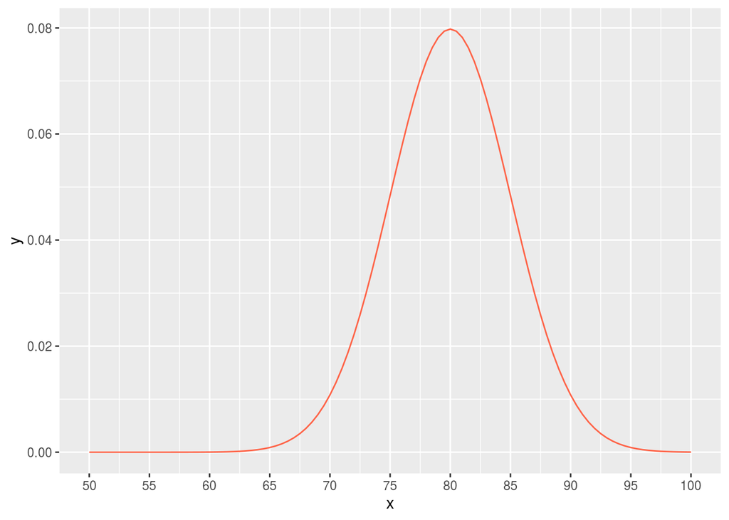

Three Normal Distributions with same means of 80, and standard deviations of 5, 10 and 20.

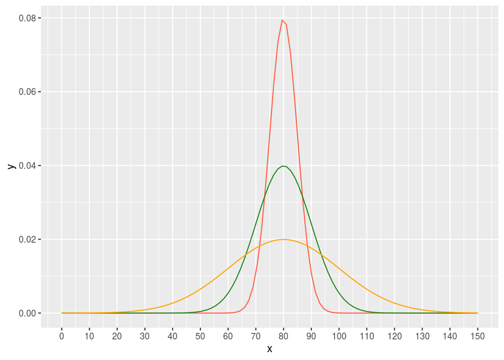

1. Match the colors to the appropiate Normal Distribution.

   N(80,5) is  
   N(80,10) is  
   N(80,20) is

## Data

We will be looking at the `weight` variable from Lab 3 from North Carolina birth data set.

The first step in deciding if your variable can be modeled with a normal distribution is to see if the distribution is bell shaped. We’ll use the histogram will show the distribution. Let’s also color our `weight` by `premie` to check if the levels of **premie** and **full term** have different distributions.

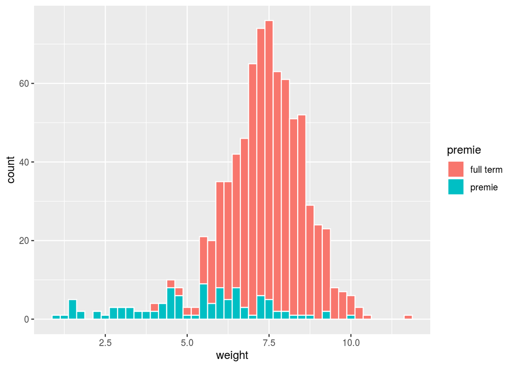

```r
ggplot(nc, aes(weight, fill=premie))+
  geom_histogram(binwidth=0.25,color="white")
```

The long left tail is concerning, let’s restrict our model to just include full-term births and create a new data frame of `nc_ft` containing only fullterm babies.

```r
nc_ft <- nc %>%
  filter(premie=="full term")
```

Let’s see the new histogram for the `weight` variable of `nc_ft`.

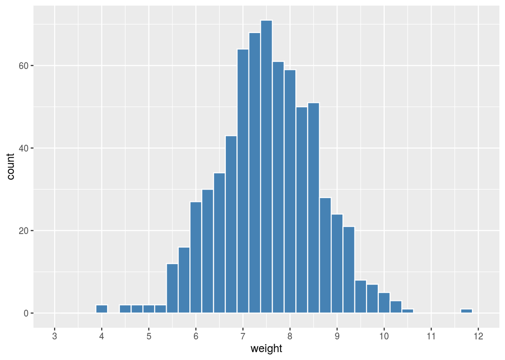

```r
ggplot(nc_ft, aes(weight ))+
  geom_histogram(binwidth=0.25,color="white", fill="steelblue")+
  scale_x_continuous(limits=c(3, 12), breaks=c(seq(3,12, by=1)))
```

2. Describe the above distribution (shape, center, variation)

## Assessing normality

In your description of the distributions, did you use words like *bell-shaped* or *normal*? It’s tempting to say so when faced with a unimodal symmetric distribution.

To see how accurate that description is, you can plot a normal distribution curve on top of a histogram to see how closely the data follow a normal distribution. This normal curve should have the same mean and standard deviation as the data.

Step 1 - Calculate Mean and Standard Deviation of `nc_ft`’s `weight` using `mean` and `sd` functions.

```r
mean_nc = mean(nc_ft$weight)
sd_nc = sd(nc_ft$weight)
mean_nc
```

```
## [1] 7.509193
```

```r
sd_nc
```

```
## [1] 1.051287
```

Step 2 - Use calculated `mean_nc` and `sd_nc` to create the normal curve

Use a density histogram as the backdrop and use the `stat_function` to overlay a normal probability curve. The difference between a frequency histogram and a density histogram is that while in a frequency histogram the *heights* of the bars add up to the total number of observations, in a density histogram the *areas* of the bars add up to 1. The area of each bar can be calculated as simply the height *times* the width of the bar. Using a density histogram allows us to properly overlay a normal distribution curve over the histogram since the curve is a normal probability density function that also has area under the curve of 1. Frequency and density histograms both display the same exact shape; they only differ in their y-axis. You can verify this by comparing the frequency histogram you constructed earlier and the density histogram created by the commands below.

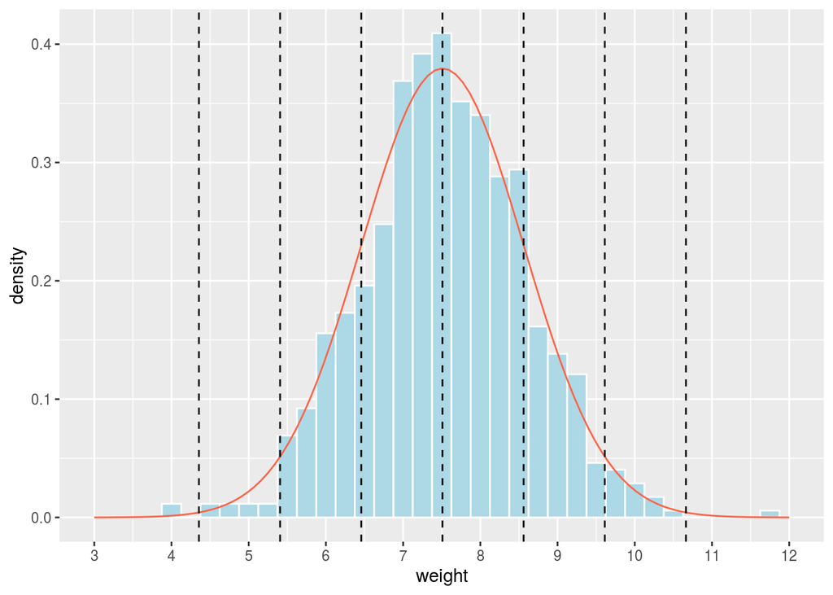

```r
ggplot(nc_ft, aes(x=weight)) +
  geom_blank() +
  geom_histogram(binwidth=0.25,color="white", fill="lightblue", aes(y=..density..)) +
  stat_function(fun = dnorm, args = c(mean = mean_nc, sd = sd_nc), col = "tomato")+
  scale_x_continuous(limits=c(3, 12), breaks=c(seq(3,12, by=1)))+
  geom_vline(xintercept=c(mean_nc,mean_nc+sd_nc, mean_nc+2*sd_nc, mean_nc+3*sd_nc, mean_nc-sd_nc, mean_nc-2*sd_nc, mean_nc-3*sd_nc), linetype="dashed")
```

After initializing a blank plot with `geom_blank()`, the `ggplot2` package (within the `tidyverse`) allows us to add additional layers. The first layer is a density histogram. The second layer is a statistical function – the density of the normal curve, `dnorm`. We specify that we want the curve to have the same mean and standard deviation as the column of babies birth weight. The argument `col` simply sets the color for the line to be drawn. If we left it out, the line would be drawn in black.

3. Based on the this plot, does it appear that the data follow a nearly normal distribution?

## Evaluating the normal distribution

Eyeballing the shape of the histogram is one way to determine if the data appear to be nearly normally distributed, but it can be frustrating to decide just how close the histogram is to the curve. An alternative approach involves constructing a normal probability plot, also called a normal Q-Q plot for “quantile-quantile”.

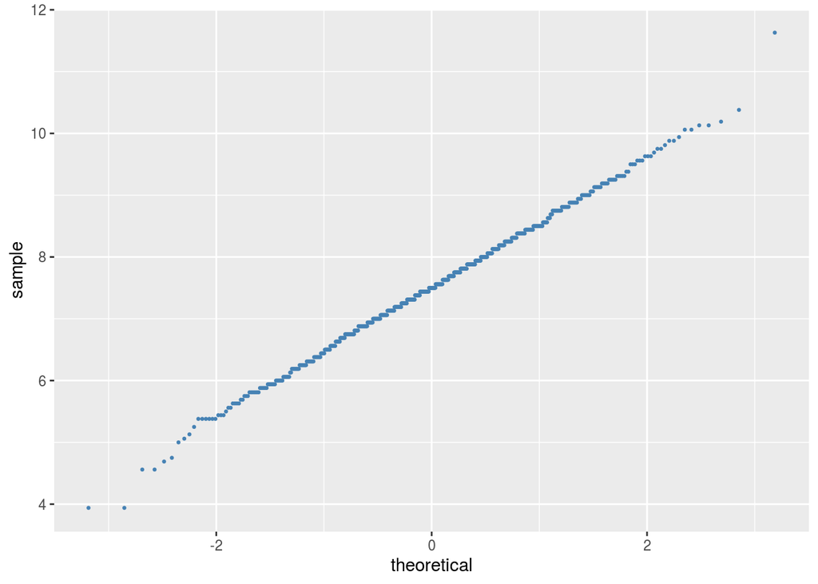

```r
ggplot(data = nc_ft, aes(sample = weight)) +
  geom_point(stat = "qq", color="steelblue", size=0.5)
```

This time, you can use the `geom_point()` layer, while specifying that you will be creating a Q-Q plot with the `stat` argument. It’s important to note that here, instead of using `x` instead `aes()`, you need to use `sample`.

The x-axis values correspond to the quantiles of a theoretically normal curve with mean 0 and standard deviation 1 (i.e., the standard normal distribution). The y-axis values correspond to the quantiles of the original unstandardized sample data. However, even if we were to standardize the sample data values, the Q-Q plot would look identical. A data set that is nearly normal will result in a probability plot where the points closely follow a diagonal line. Any deviations from normality leads to deviations of these points from that line.

You’re left with the same problem that we encountered with the histogram above: how close is close enough?

A useful way to address this question is to rephrase it as: what do probability plots look like for data that I *know* came from a normal distribution? We can answer this by simulating data from a normal distribution using `rnorm`.

```r
sim_norm <- data.frame(sim_values = rnorm(n = nrow(nc_ft), mean = mean_nc, sd = sd_nc))
```

The first argument indicates how many numbers you’d like to generate, which we specify to be the same number of menu items in the `nc_ft` data set using the `nrow()` function. The last two arguments determine the mean and standard deviation of the normal distribution from which the simulated sample will be generated. You can take a look at the shape of our simulated data set, `sim_norm`, as well as its normal probability plot.

4. Below is a comparison of the simulated data (in red) along with the `nc_ft` real data. Do all of the points fall on the line? How does this plot compare to the probability plot for the real data?

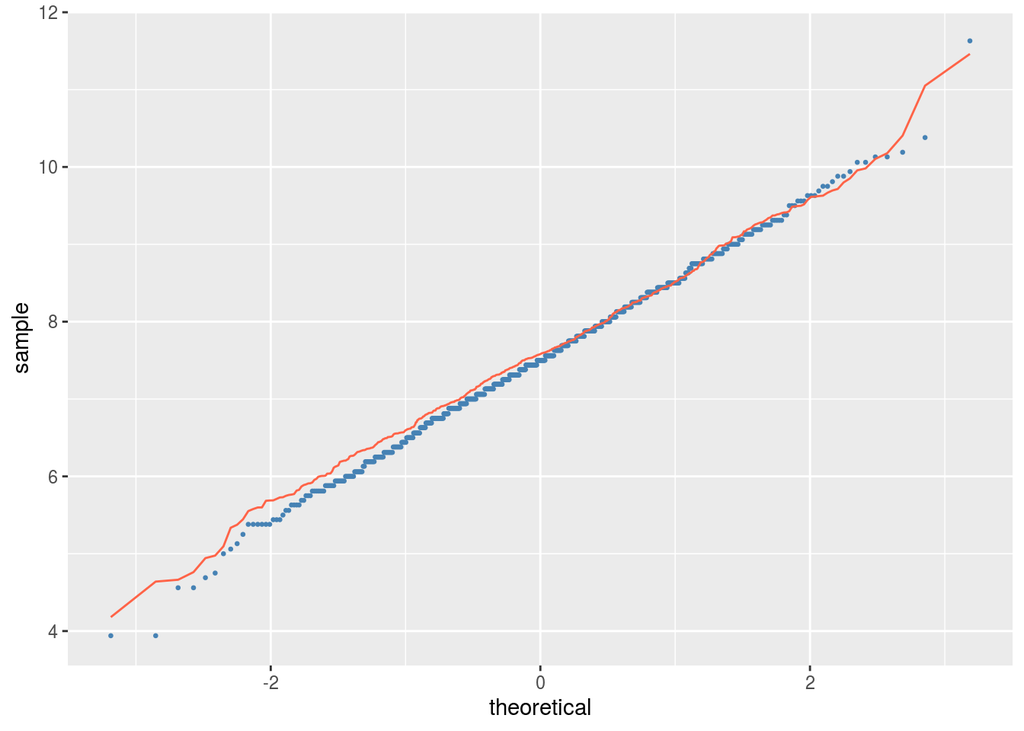

```r
ggplot(data = nc_ft, aes(sample = weight)) +
  geom_point(stat = "qq", color = "steelblue", size=0.5)+
  geom_line(data=sim_norm,aes(sample=sim_values),stat = "qq", color="tomato")
```

Even better than comparing the original plot to a single plot generated from a normal distribution is to compare it to many more plots using the following function. It shows the Q-Q plot corresponding to the original data in the top left corner, and the Q-Q plots of 8 different simulated normal data. It may be helpful to click the zoom button in the plot window.

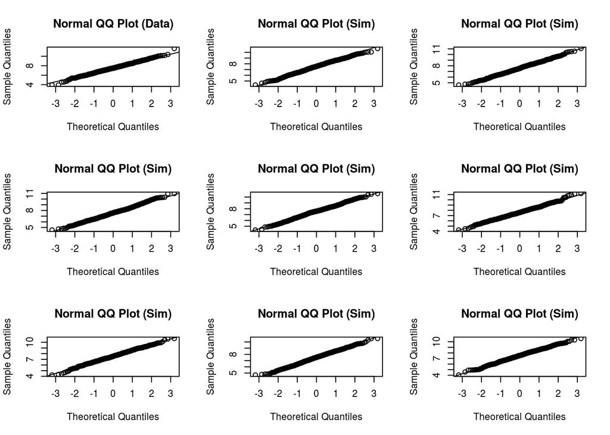

```r
source("http://www.jkarreth.net/files/qqnormsim.R")  ## loading the qqnormsim function
qqnormsim(nc_ft$weight)
```

5. Does the normal probability plot for the `weight` look similar to the plots created for the simulated data? That is, do the plots provide evidence that the `weight` is nearly normal?

## Normal probabilities

Okay, so now you have a slew of tools to judge whether or not a variable is normally distributed. Why should you care?

It turns out that statisticians know a lot about the normal distribution. Once you decide that a random variable is approximately normal, you can answer all sorts of questions about that variable related to probability. Take, for example, the question of, “What is the probability that a randomly chosen baby will have a birth weigth greater than 8 pounds?”

Since we assume that the birth `weight` is normally distributed (a very close approximation is also okay), we can find this probability by calculating a Z score and consulting a Z table (also called a normal probability table). In R, this is done in one step with the function `pnorm()`.

```r
1 - pnorm(q = 8, mean = mean_nc, sd = sd_nc)
```

```
## [1] 0.320299
```

Note that the function `pnorm()` gives the area under the normal curve below a given value, `q`, with a given mean and standard deviation. Since we’re interested in the probability that a baby is heavier than 8 pounds, we have to take one minus that probability.

Assuming a normal distribution has allowed us to calculate a theoretical probability. If we want to calculate the probability empirically, we simply need to determine how many babies have a weight greater than 8 then divide this number by the total sample size.

```r
nc_ft %>%
  filter(weight > 8) %>%
  summarise(percent = n() / nrow(nc_ft))
```

```
##     percent
## 1 0.3025937
```

Although the probabilities are not exactly the same, they are reasonably close. The closer that your distribution is to being normal, the more accurate the theoretical probabilities will be.

6. Use both methods above to determine the probability that for a birth `weight` less than 7 pounds. Comment on why they are differeny (Hint: look at your graphics)

## More Practice

We have just created a procedure to assess if a quantitative variable follows a Normal Distribution.

**Step 1**: Graph a density histogram and a normal curve (with mean and sd generated from data set)

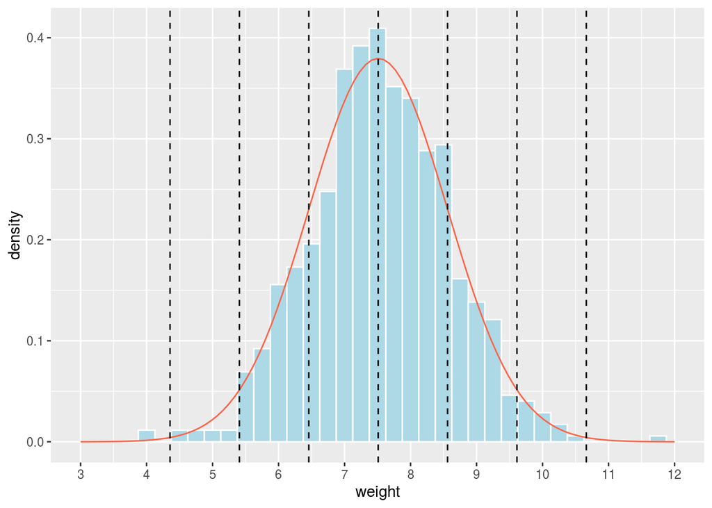

**Step 2**: Graph a QQ Plot of the actual data and simulated normal data

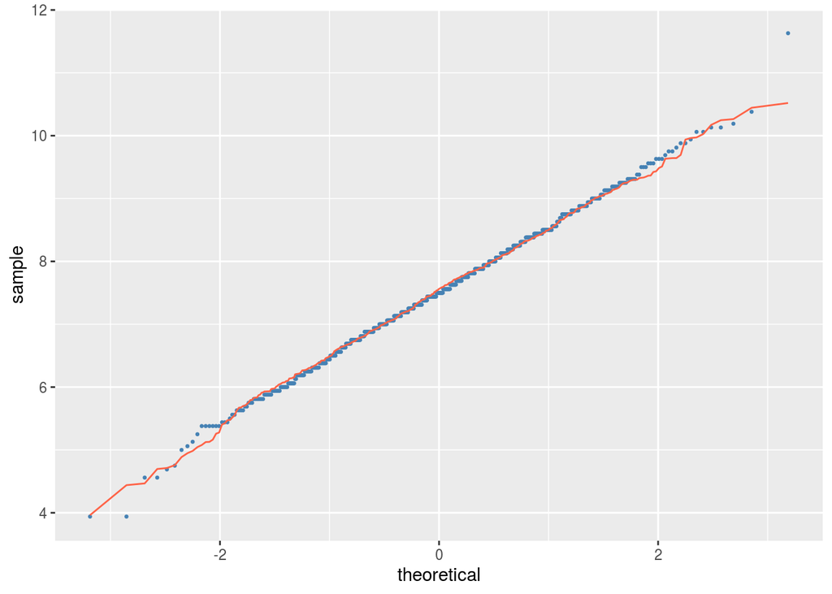

**Decision**: If normal curve and simulated normal data are similar, the data can be approximated by a normal distribution.

Analysize `mage` and `gained` using the 2 steps above and decide if they can be modeled with the Normal Distribution.

7. Complete the analysis outlined above for `mage` and make a decision if `mage` can be modeled with the Normal Distribution (i.e., Step 1 and Step 2). Test your decision by calculating the probability that a mother’s age is less than 21.
8. Complete the analysis outlined above for `gained` and make a decision if `gained` can be modeled with the Normal Distribution. Test your decision by calculating the probability that a mother’s weight gained is more than 40.

This is an adaption of an OpenIntro Labs that is released under a [Creative Commons Attribution-ShareAlike 3.0 Unported](http://creativecommons.org/licenses/by-sa/3.0).